# Weighted ensemble scores

## Rationale

The ensemble of two top performing teams outperforms individual models. In addition, the two teams have differences in performance according to the patients tested.

Therefore, instead of make a simple mean of the scores, it would be appropiate to weight each model according to some kind of stratification (i.e. clinical data stratifications such as age, BMI, etc).

The solution proposed is to perform a weighted average of the two models based on the performances obtained in train set. The final scores will be obtained by means of the following equation.

$$\frac{w_{sb2} * score_{sb2} + w_{denver} * score_{denver}}{w_{sb2} + w_{denver}}$$
Since we already have the scores of each models through all the patients, the objective is to build a set of rules to define the weights of each model.

First, based on scores from train datasets we have stratified patients following FINRISK 2002 ranges:

```
##
##  (0,34] (34,44] (44,54] (54,64] (64,75]
##     544     723     822    1007     519
```

For each range we calculated the Holmes test and C-Index for both models (SB2 and DenverFINRISKHacky) as in the challenge. We can see the performances of each model throught age ranges:

|  | Age_str | holmes_denver | holmes_sb2 | c_denver | c_sb2 |
| --- | --- | --- | --- | --- | --- |
| 1 | (0,34] | 0.569583098959221 | 0.626626035910622 | 0.966037735849057 | 0.849056603773585 |
| 2 | (34,44] | 0.0588318039693754 | 0.0839417320676308 | 0.693165467625899 | 0.605935251798561 |
| 3 | (44,54] | 6.32414484652667e-05 | 0.105016432647323 | 0.678664099774002 | 0.738511760274546 |
| 4 | (54,64] | 4.01530954047597e-12 | 0.00371444392853326 | 0.695399347720491 | 0.778141697314551 |
| 5 | (64,75] | 1.95843553016352e-08 | 0.000738738274209425 | 0.677813948900069 | 0.726620301864457 |

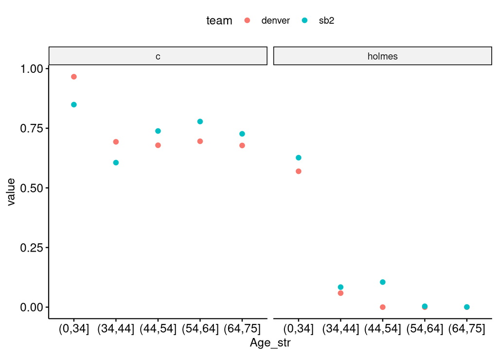

Thus, in order to obtain a weight by each model on a specific age interval, we will take into account both metrics: C-index and Holmes test. Now, based on these metrics we can summarise the performance adding new variables on the data.

```r
weights <-
  weights %>%
  mutate(
    # holmes
    holmes_sb2_cat = ifelse(holmes_sb2 > 0.05, "calibrated", "non-calibrated"),
    holmes_denver_cat = ifelse(holmes_denver > 0.05, "calibrated", "non-calibrated"),

    # c-index
    better_c = ifelse(c_denver - c_sb2 < 0, "sb2", "denver"),

    # weigths
    w = -log10(holmes_sb2) - (-log10(holmes_denver)),
    w_sb2 = ifelse(w < 0, (c_sb2 * 10) + abs(w), c_sb2 * 10),
    w_denver = ifelse(w > 0, (c_denver * 10) + abs(w), c_denver * 10),
  )

DT::datatable(weights)
```

|  | Age_str | holmes_denver | holmes_sb2 | c_denver | c_sb2 | holmes_sb2_cat | holmes_denver_cat | better_c | w | w_sb2 | w_denver |
| --- | --- | --- | --- | --- | --- | --- | --- | --- | --- | --- | --- |
| 1 | (0,34] | 0.569583098959221 | 0.626626035910622 | 0.966037735849057 | 0.849056603773585 | calibrated | calibrated | denver | -0.0414513414270638 | 8.53201737916291 | 9.66037735849057 |
| 2 | (34,44] | 0.0588318039693754 | 0.0839417320676308 | 0.693165467625899 | 0.605935251798561 | calibrated | calibrated | denver | -0.154365760836902 | 6.21371827882251 | 6.93165467625899 |
| 3 | (44,54] | 6.32414484652667e-05 | 0.105016432647323 | 0.678664099774002 | 0.738511760274546 | calibrated | non-calibrated | sb2 | -3.22025545310869 | 10.6053730558541 | 6.78664099774002 |
| 4 | (54,64] | 4.01530954047597e-12 | 0.00371444392853326 | 0.695399347720491 | 0.778141697314551 | non-calibrated | non-calibrated | sb2 | -8.96617477613732 | 16.7475917492828 | 6.95399347720491 |
| 5 | (64,75] | 1.95843553016352e-08 | 0.000738738274209425 | 0.677813948900069 | 0.726620301864457 | non-calibrated | non-calibrated | sb2 | -4.57658132094892 | 11.8427843395935 | 6.77813948900069 |

Below are the rules that we follow to add weights to each model:

1. The main weight of each model will be based on the value of C-Index multiplied by 10 in the specific age range.
2. Regarding Holmes values, we calculated the -log10() for each model in each age range. Then, we subtracted the value of the SB2 model minus the value obtained in the Denver model. In this way, the column w was obtained. This represents two things: i) the sign is telling us which model had better calibration (negative = SB2, positive = denver) and ii) the absolute value indicates the magnitude of the difference between the two teams. Therefore, the higher the values, the greater the difference.
3. Based on this, the aim is to give more weight to models with a high C-index performance, but to penalise those that are not well calibrated. For this, the weight of each model was defined by the $Cindex * 10 + abs(w)$

Now, we can calculate the weighted mean based on these weights.

```r
ensemble <-
  left_join(res, weights[, c("Age_str", "w_sb2", "w_denver")], by = "Age_str") %>%
  mutate(
    mean = (Score_sb2 + Score_denver) / 2,
    w_mean = (w_sb2 * Score_sb2 + w_denver * Score_denver) / (w_sb2 + w_denver)
  )

DT::datatable(ensemble)
```

|  | Age_str | Score_sb2 | Score_denver | holmes_denver | holmes_sb2 | c_denver | c_sb2 | w_sb2 | w_denver | mean | w_mean |
| --- | --- | --- | --- | --- | --- | --- | --- | --- | --- | --- | --- |
| 1 | (54,64] | 0.0853060495589985 | 0.412735845164836 | 4.01530954047597e-12 | 0.00371444392853326 | 0.695399347720491 | 0.778141697314551 | 16.7475917492828 | 6.95399347720491 | 0.249020947361917 | 0.181373238362089 |
| 2 | (0,34] | 0.00164512400492978 | 0.000451282893394408 | 0.569583098959221 | 0.626626035910622 | 0.966037735849057 | 0.849056603773585 | 8.53201737916291 | 9.66037735849057 | 0.00104820344916209 | 0.00101118021633985 |
| 3 | (34,44] | 0.00706987589846331 | 0.0161168206567892 | 0.0588318039693754 | 0.0839417320676308 | 0.693165467625899 | 0.605935251798561 | 6.21371827882251 | 6.93165467625899 | 0.0115933482776263 | 0.0118403983594229 |
| 4 | (34,44] | 0.00313751362129955 | 0.00617058903384686 | 0.0588318039693754 | 0.0839417320676308 | 0.693165467625899 | 0.605935251798561 | 6.21371827882251 | 6.93165467625899 | 0.0046540513275732 | 0.00473687724823283 |
| 5 | (54,64] | 0.0479276922754115 | 0.194221674988756 | 4.01530954047597e-12 | 0.00371444392853326 | 0.695399347720491 | 0.778141697314551 | 16.7475917492828 | 6.95399347720491 | 0.121074683632084 | 0.0908500281369812 |
| 6 | (64,75] | 0.500108524767693 | 0.535533551431287 | 1.95843553016352e-08 | 0.000738738274209425 | 0.677813948900069 | 0.726620301864457 | 11.8427843395935 | 6.77813948900069 | 0.51782103809949 | 0.513003468882049 |
| 7 | (44,54] | 0.00938926073781232 | 0.0254543033529054 | 6.32414484652667e-05 | 0.105016432647323 | 0.678664099774002 | 0.738511760274546 | 10.6053730558541 | 6.78664099774002 | 0.0174217820453589 | 0.015658096337074 |
| 8 | (54,64] | 0.0787186339743972 | 0.21953686501005 | 4.01530954047597e-12 | 0.00371444392853326 | 0.695399347720491 | 0.778141697314551 | 16.7475917492828 | 6.95399347720491 | 0.149127749492224 | 0.12003439622135 |
| 9 | (54,64] | 0.0607528045468118 | 0.149076215319974 | 4.01530954047597e-12 | 0.00371444392853326 | 0.695399347720491 | 0.778141697314551 | 16.7475917492828 | 6.95399347720491 | 0.104914509933393 | 0.0866667008761873 |
| 10 | (54,64] | 0.0275917344129344 | 0.0533430064968186 | 4.01530954047597e-12 | 0.00371444392853326 | 0.695399347720491 | 0.778141697314551 | 16.7475917492828 | 6.95399347720491 | 0.0404673704548765 | 0.0351471015493458 |

[output cut: 3605 more lines]